# Industrial Energy Dashboard Documentation

## Data Update Pipeline Structure

All data update scripts are stored in `tools/data_pipeline`. The diagram shows the automated workflow that generates a final integrated dataset used in the dashboard.

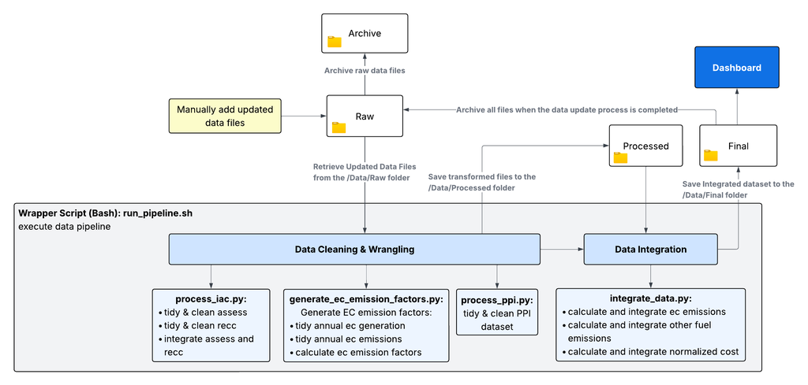

*Data processing pipeline from raw files to dashboard*

## Local Data Update Process

### When to Use Local Processing

- 🧪 **Testing new data** before production deployment
- 🔧 **Development work** or making code changes
- 🏠 **Personal analysis** or data exploration
- 🐛 **Debugging** data processing issues
- 📊 **Verifying data quality** before server deployment

### Prerequisites for Local Processing

#### 1. System Requirements

- Docker installed and running
- Dashboard repository cloned locally
- Access to new data files

#### 2. Environment Setup

Follow the Dashboard Installation Guide to install the dashboard in a local environment.

#### 3. Data Folder Structure

2. Configure Folder Structure in `Dashboard/Data` directory

#### Folder Structure Configuration

Table 1: Data folder organization and workflow

| Folder | Purpose | Content | Important Notes |
| --- | --- | --- | --- |
| **`raw/`** | New data files | Only updated files that have changed | • Files moved to `archive/` after processing • Don’t re-upload unchanged files • Source for pipeline input |
| **`processed/`** | Intermediate files | • Auto-generated pipeline files • Static reference files (e.g., `arc_descriptions.csv`) | • Edit static files directly in this folder if needed • Contains both generated and manual files |
| **`final/`** | Dashboard data | Fully integrated dataset (`iac_integrated.csv`) | • Auto-generated after pipeline runs • Used directly by dashboard |
| **`archive/`** | Historical files | Original raw files after processing | • Automatic backup of processed files • For reference and rollback |

#### 4. Update Data

Follow the steps below to update the dashboard data on a local computer.

#### Step 1: Upload Updated Files

Table 2: Required data files with naming conventions

[output not shown]

**Upload Process:**

1. Place new files in the `data/raw/` folder

**Important**

**Important**: Only upload files that changed since the last data update. Unchanged files are already stored in the `processed/` folder and do not need to be re-uploaded.

#### Step 2: Process Data

From the dashboard repository root folder, run the data processing pipeline.

##### Option 1: Docker (Recommended)

```bash
# Build and run the pipeline
docker-compose --profile pipeline build
docker-compose --profile pipeline run --rm industrialenergy_datapipeline
```

##### Option 2: Direct Script Execution

**Important**

**Prerequisites**: Make sure your conda environment is activated before running the script:

```bash
conda activate industrialenergy  # or your environment name
```

```bash
# Make script executable (only needed once)
chmod +x tools/data_pipeline/run_pipeline.sh

# Run the pipeline (from dashboard root directory)
./tools/data_pipeline/run_pipeline.sh
```

##### What to Expect

- **Build time**: 2-3 minutes (ensures fresh environment)
- **Processing time**: 3-5 minutes for data pipeline
- **Total time**: ~5-8 minutes

#### Step 3: Verify Output

Check that these files were created: - `data/final/iac_integrated.csv` - `data/final/iac_metadata.json`

## Server Data Update Process

#### When to Use Server Processing

- 🚀 **Production data updates** for live dashboard
- 👥 **Team updates** when multiple people need access

### Prerequisites for Server Processing

- SSH access to Bren server
- Credentials for server connection. Contact compute@bren.ucsb.edu to request access.

**Note**

For SSH connection instructions, consult the guide [Using VS Code to SSH into Bren Servers](https://bren.zendesk.com/hc/en-us/articles/34725004003988-Using-VS-Code-to-SSH-into-Bren-Servers)

#### Step 1: Access Bren Server

Path: apps.bren.ucsb.edu/capstone/industrialenergy/dashboard/

```bash
ssh username@bren-server
cd capstone/industrialenergy/dashboard/  # Navigate to dashboard directory
```

#### Step 2: Upload New Data to Server

Table 3: Required data files with naming conventions

| Expected File Name | Example | Data Source |
| --- | --- | --- |
| `ARC_PPI_YYYY.xlsx` | `ARC_PPI_2024.xlsx` | [Google Drive](https://drive.google.com/drive/folders/1-DjFb8lP9sdhHdnQdCWJLMNzRa0PeY7n?usp=sharing) |
| `IAC_Database_YYYYMMDD.xls` | `IAC_Database_20250518.xlsx` | [IAC Website](https://iac.university/download) |
| `annual_generation_state_YYYY.xls` | `annual_generation_state_2024.xls` | [EIA State Generation Data](https://www.eia.gov/electricity/data.php#elecenv) |
| `emission_annual_YYYY.xlsx` | `emission_annual_2024.xlsx` | [EIA Annual Emissions Data](https://www.eia.gov/electricity/data.php#elecenv) |

From your **local machine**, upload the data files to the server:

**Important**

**Important**: Only upload files that changed since the last data update. Unchanged files are already stored in the `processed/` folder and do not need to be re-uploaded.

Example:

```bash
# Upload raw data files from local folder to server
scp IAC_Database_20250215.xls username@bren-server:apps.bren.ucsb.edu/capstone/industrialenergy/dashboard/data/raw
scp ARC_PPI_2024.xlsx username@bren-server:apps.bren.ucsb.edu/capstone/industrialenergy/dashboard/data/raw
```

#### Step 3: Process Data on Server

Back on the **server terminal**: Ensure you are in the dashboard root folder `capstone/industrialenergy/dashboard`

```bash
# Build and run the pipeline
docker-compose --profile pipeline build
docker-compose --profile pipeline run --rm industrialenergy_datapipeline
```

#### Step 4: Verify Server Results

Check the processed files were created:

```bash
ls -la data/final/
# Should show updated timestamps for:
# - iac_integrated.csv
# - iac_metadata.json
```

#### Step 5: Test Live Dashboard

Visit the live dashboard: [Industrial Energy Efficiency Dashboard/](https://industrialenergy.apps.bren.ucsb.edu/dashboard)

Verify:  
- [ ] “Based on IAC assessment data from: [**New Date**]” shows correct date  
- [ ] Charts load without errors  
- [ ] Data looks reasonable